# 第8回 遺伝子発現データで、教師あり解析を一周する

手がかりが匹数より多いとき

# 導入

## ここまでの道具

① 場面●○○○○

- 前処理、線形回帰、交差検証、正則化、パイプライン
- 教師あり学習（答えの列がある解析）の道具がそろった
- 今日は、新しいデータで最初から最後まで一周する

## 今日のデータは横長

① 場面●●○○○

- 遺伝子の発現量のデータ
- 手がかりの列が、行の数よりずっと多い
- これまでの道具を、そのまま使えるか

## 場面：眼科の研究者

① 場面●●●○○

- あなたは、目の病気を研究する眼科の研究者
- TRIM32は、網膜の病気（バルデー・ビードル症候群）の原因遺伝子の1つとして報告された（Chiangほか, 2006）

## 遺伝子は一緒に動く

① 場面●●●●○

- 遺伝子は、いくつもが一緒に強まったり弱まったりする
- TRIM32と一緒に動く遺伝子が分かれば、働きを考える手がかりになる

## 決めたいこと

① 場面●●●●●

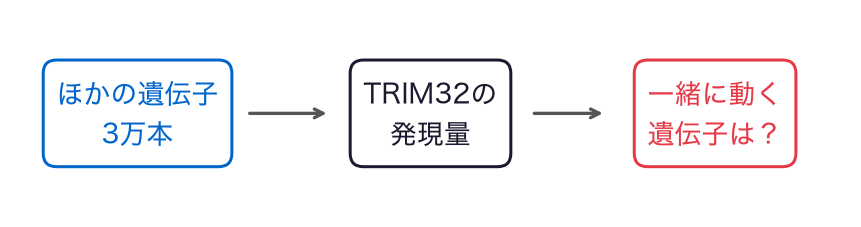

- ほかの遺伝子からTRIM32を当て、一緒に動く遺伝子を探す

## 手元のデータ

② 手元のデータ●○

- 交配したラット120匹の目の組織で測った発現量（Scheetzほか, 2006。NCBI GEOのGSE5680）
- 1行が1匹。列はプローブ（遺伝子の断片を測る印）ごとの発現量
- 値はlog2。1大きいと発現量が2倍

## 遺伝子の名前は別の表

② 手元のデータ●●

- プローブと遺伝子の名前の対応は、`rat_eye_genes.csv`
- 名前が分かっているプローブは、7割ほど
- TRIM32のプローブは、先頭の列`TRIM32`に出してある

## 最後に出す答え

③ 今日の問い●○

- ほかの遺伝子からTRIM32を当てる式と、その当たり（MAE）
- 一緒に動く遺伝子について、何が言えて、何が言えないか

## 今日の問い

③ 今日の問い●●

ほかの遺伝子の発現量から、TRIM32の発現量を当てられるか？ 一緒に動く遺伝子を特定できるか？

## もう1つのねらい：スクリプト

④ もう1つのねらい●○

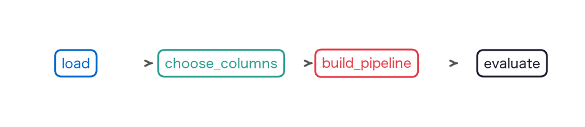

- 自分のコードを、関数に分けた1本のスクリプトにまとめられるようになる

## 引数を変えて比べ直す

④ もう1つのねらい●●

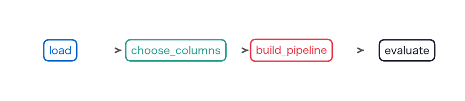

- 読む・列を選ぶ・パイプラインを作る・評価する、を関数にする
- 引数を変えるだけで、候補を比べ直せるようにする

## 今日の道筋

⑤ 今日の問い●

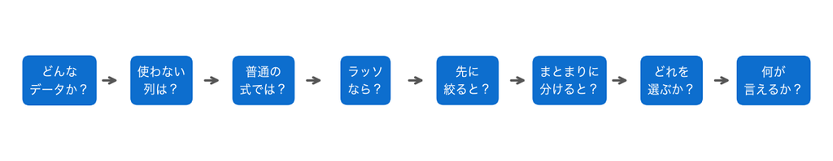

- 8つの小さな問いに答えていく

# 0. 準備

## まずは道具とデータ

- 第8回のノートを開き、上から順にセルを実行する
- 2つの表を読み込み、訓練とテストに分ける

## お手本：道具を呼び出す

0節 ① 道具とデータ●○○

```python
import numpy as np
import pandas as pd
import matplotlib.pyplot as plt
from sklearn.linear_model import LinearRegression, LassoCV
from sklearn.preprocessing import StandardScaler
from sklearn.pipeline import make_pipeline
from sklearn.model_selection import train_test_split, KFold
from sklearn.model_selection import cross_val_score
from sklearn.feature_selection import SelectKBest, f_regression
from sklearn.base import BaseEstimator
from scipy.cluster.hierarchy import linkage, fcluster, dendrogram
```

- 列を絞る道具、階層的クラスタリングの道具（scipy）などが加わる

## お手本：2つの表を読み込む

0節 ① 道具とデータ●●○

```python
# データはこのリポジトリから読み込む
DATA_DIR = ('https://raw.githubusercontent.com/k0heiun0/'
            'applied_exercise_preview/main/shared/data')
df = pd.read_csv(f'{DATA_DIR}/rat_eye_full.csv.gz', index_col=0)
genes = pd.read_csv(f'{DATA_DIR}/rat_eye_genes.csv', index_col=0)
print(df.shape)
print(genes.shape)
```

- 発現量の表は圧縮してある（`.csv.gz`）。`read_csv`はそのまま読める
- `index_col=0`で、1列目を行の名前にする

## 120行 × 31,099列

0節 ① 道具とデータ●●●

```
(120, 31099)
(31099, 2)
```

- 120匹に、TRIM32の列とプローブの列が並ぶ
- 遺伝子の名前の表は、プローブ1本が1行

## お手本：答えと手がかりに分ける

0節 ② 訓練とテスト●○

```python
y = df['TRIM32']
X = df.drop(columns='TRIM32')
X_tr, X_te, y_tr, y_te = train_test_split(
    X, y, test_size=0.25, random_state=0)
print(X.shape[1], '本のプローブ')
print(len(X_tr), len(X_te))
```

- 120匹しかいないので、テストは25%の30匹にする

## 訓練90匹、テスト30匹

0節 ② 訓練とテスト●●

```
31098 本のプローブ
90 30
```

- 手がかりは31,098本。テストは、最後に1回だけ使う

## やってみよう：0節

0節 ③ 確かめる●

- 0節のセルを上から実行し、表の大きさと匹数を確かめる

動画の人は、ここで一時停止。

# 1. どんなデータか？

## 中身をのぞく

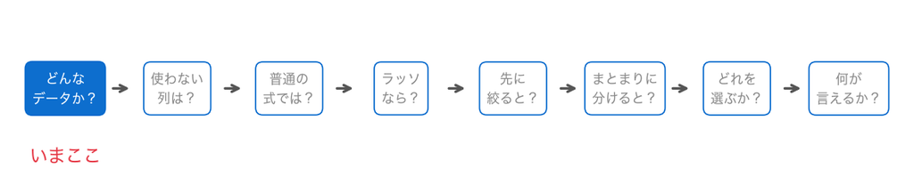

- 表が読めた。式を作る前に、中身をのぞく

## お手本：表の左上

1節 ① 中身●○

```python
X_tr.iloc[:3, :4]
```

| sample | 1367452_at | 1367453_at | 1367454_at | 1367455_at |
| --- | --- | --- | --- | --- |
| GSM130572 | 10.6614 | 9.6472 | 9.3595 | 10.8762 |
| GSM130645 | 10.8434 | 9.6382 | 9.3003 | 10.8488 |
| GSM130639 | 10.7260 | 9.5971 | 9.5933 | 10.8887 |

- 列の名前の`1367452_at`などが、プローブの番号

## log2の発現量

1節 ① 中身●●

## 変えてみる：TRIM32を見る

1節 ② 答えの列●○

```python
print(y_tr.describe().round(3))
```

```
count    90.000
mean      8.388
std       0.152
min       7.381
25%       8.323
50%       8.405
75%       8.459
max       8.753
```

## ラットごとの違いは小さい

1節 ② 答えの列●●

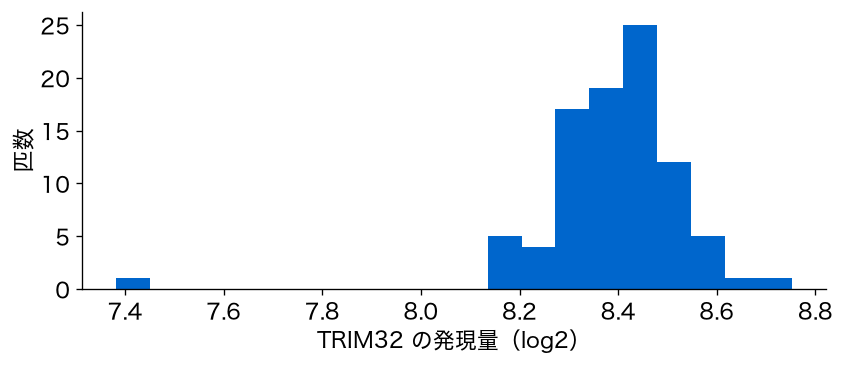

- 平均8.388、標準偏差0.152。log2で0.1や0.2の違いを当てる
- 外れの物差しは、これまでと同じMAE

## 列が、行よりずっと多い

1節 ③ 横長のデータ●○

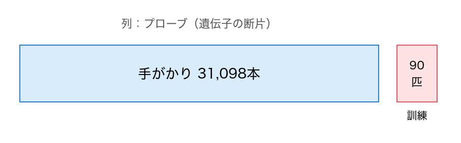

- 手がかりは31,098本、訓練は90匹

## 名前：p > n

1節 ③ 横長のデータ●●

```python
print(round(X_tr.shape[1] / X_tr.shape[0], 1))
```

```
345.5
```

- 手がかりの数$p$が、行の数$n$の345.5倍。$p > n$のデータと呼ぶ
- 第5回の完全な多重共線性より、ずっと極端な状況

## やってみよう：1節

1節 ④ 確かめる●

- 1節のセルを実行し、TRIM32の分布と、$p / n$を確かめる

動画の人は、ここで一時停止。

# 2. どの列を使わないか？

## 答えを見ずに決める

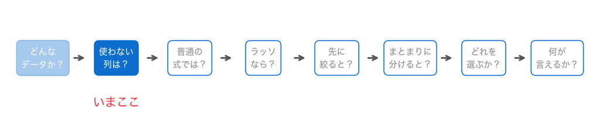

- 手がかりが3万本以上。全部を使う前に、「使わない」の判断をする（第5回）
- 大事なのは、答えのTRIM32を見ずに決めること

## 対照のプローブ

2節 ① 対照のプローブ●○○

- 遺伝子を測るためではなく、測定がうまくいったかを確かめるプローブ
- 名前が`AFFX`で始まる

## お手本：対照を数える

2節 ① 対照のプローブ●●○

```python
affx = X_tr.columns.str.startswith('AFFX')
print(affx.sum(), '本が対照のプローブ')
```

```
57 本が対照のプローブ
```

- `str.startswith('AFFX')`：列の名前が`AFFX`で始まればTrue
- `sum()`でTrueを数える（第6回）

## 変えてみる：対照を外す

2節 ① 対照のプローブ●●●

```python
X_tr = X_tr.loc[:, ~affx]
X_te = X_te.loc[:, ~affx]
print(X_tr.shape[1], '本')
```

```
31041 本
```

- `X_tr.loc[:, 条件]`：条件がTrueの列だけを残す。`~`はTrueとFalseを入れ替える

## 発現の低いプローブ

2節 ② 発現の低いプローブ●○○○○○○

- 測った値が信頼できない列は、使わないほうがよい（第5回）
- 発現が低いと、機械が拾う値は雑音に近くなる

## お手本：発現の平均を見る

2節 ② 発現の低いプローブ●●○○○○○

```python
mean_tr = X_tr.mean()                  # プローブごとの平均（訓練）
print(round(mean_tr.median(), 2))
plt.hist(mean_tr, bins=50)
plt.axvline(mean_tr.median(), color='gray', ls='--')
plt.xlabel('プローブの発現量の平均（log2）')
plt.ylabel('本数')
plt.show()
```

## 低いほうにも山

2節 ② 発現の低いプローブ●●●○○○○

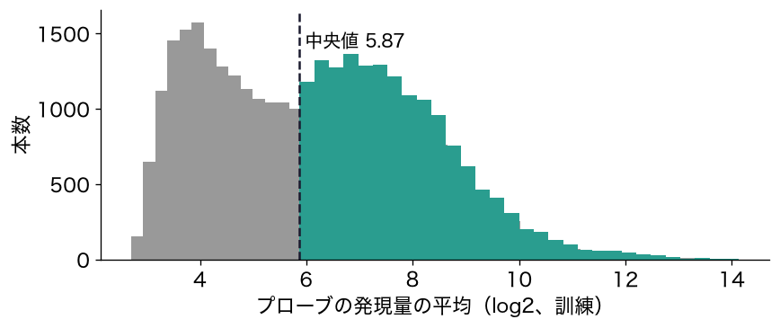

- 平均の中央値は5.87。低いほう（3〜5）にも山がある

## 中央値以下は使わない

2節 ② 発現の低いプローブ●●●●○○○

- 平均が中央値以下の半分を、発現の低いプローブとして使わない
- 中央値で切るのは、決め方の1つにすぎない
- 決めた基準は、報告に書き残す

## TODO①：残る列を数える

2節 ② 発現の低いプローブ●●●●●○○

```python
# TODO: 平均が中央値より大きい列の印 keep を作り、残す数・外す数を出す
# ヒント: keep = mean_tr > mean_tr.median()
#         keep.sum() と (~keep).sum()
...
```

- Trueの数が残る列、Falseの数が外す列

## やってみよう：2節とTODO①

2節 ② 発現の低いプローブ●●●●●●○

- 2節のお手本と「変えてみる」のセルを実行する
- TODO①で、残る列と外す列を数える

動画の人は、ここで一時停止。

## 答え合わせ：TODO①

2節 ② 発現の低いプローブ●●●●●●●

```python
keep = mean_tr > mean_tr.median()
print(keep.sum(), '本を残す')
print((~keep).sum(), '本を外す')
```

```
15520 本を残す
15521 本を外す
```

- 中央値で切ったので、ほぼ半分ずつ

## お手本：低いプローブを外す

2節 ③ 外す●○○

```python
keep = mean_tr > mean_tr.median()
X_tr = X_tr.loc[:, keep]
X_te = X_te.loc[:, keep]
print(X_tr.shape)
```

```
(90, 15520)
```

- 訓練は90匹 × 15,520本になった

## 答えは、まだ使っていない

2節 ③ 外す●●○

- ここまで、答えのTRIM32は一度も使っていない
- 平均は訓練の90匹だけで計算した（第3回の「訓練だけで決める」）

## 外すのは、当たりのためではない

2節 ③ 外す●●●

- 試すと、発現の低い半分を外しても、式の当たりはほとんど変わらない
- 外す理由は、計算を軽くし、雑音に近い列を「効いている遺伝子」と読まないため

# 3. 普通の式では？

## まずは普通の線形回帰

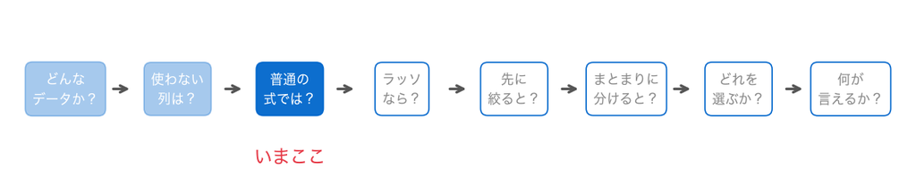

- 使う列が15,520本に決まった。これまでの線形回帰で当ててみる
- 比べる相手は、全員を訓練の平均で当てたときのMAE

## お手本：普通の線形回帰

3節 ① 普通の式●○

```python
def mae(y, pred):
    return np.abs(y - pred).mean()

ols = LinearRegression().fit(X_tr, y_tr)
print(round(mae(y_tr, ols.predict(X_tr)), 4))     # 訓練
print(round(mae(y_te, ols.predict(X_te)), 4))     # テスト
print(round(mae(y_te, y_tr.mean()), 4))           # 平均で当てると
```

## 訓練では0

3節 ① 普通の式●●

```
0.0
0.0787
0.0913
```

- 訓練のMAEは0。90匹の全員を、ぴったり当てた
- テストは0.0787で、平均で当てた0.0913より少しよいだけ

## なぜぴったり当たるのか？

3節 ② ぴったり当たる理由●○○

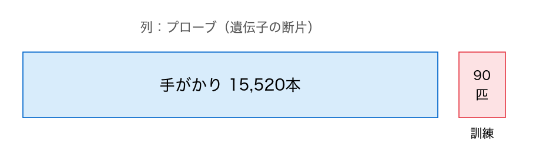

- 係数は15,520本に1つずつと切片で、15,521個。当てる相手は90匹

## 未知数が式より多い

3節 ② ぴったり当たる理由●●○

- 未知数15,521個、式90本の連立方程式
- 90匹全員をぴったり当てる係数は、無数にある

## 訓練の当たりは当てにならない

3節 ② ぴったり当たる理由●●●

- ぴったり当たるのは、式がよいからではなく、自由度が多すぎるから
- 訓練の当たりは、まったく当てにならない

## テストは最後に1回だけ

3節 ③ 比べる準備●○○

- ここからの候補の比較は、訓練の90匹の交差検証で行う（第4回）
- 比べる相手として、平均で当てたときの交差検証のMAEも出す

## お手本：平均で当てると

3節 ③ 比べる準備●●○

```python
kf = KFold(n_splits=5, shuffle=True, random_state=0)
base = []
for tr_i, te_i in kf.split(X_tr):
    base.append(mae(y_tr.iloc[te_i], y_tr.iloc[tr_i].mean()))
print(np.round(base, 4))
print(round(np.mean(base), 4))
```

```
[0.0794 0.0902 0.0787 0.0948 0.1364]
0.0959
```

## 比べる相手は0.0959

3節 ③ 比べる準備●●●

- 平均で当てると、交差検証のMAEは0.0959
- これより小さくできれば、遺伝子の情報が役に立っている

## やってみよう：3節

3節 ④ 確かめる●

- 3節のセルを実行し、訓練とテストのMAE、平均で当てたMAEを確かめる

動画の人は、ここで一時停止。

# 4. ラッソなら？

## 係数を落ち着かせる

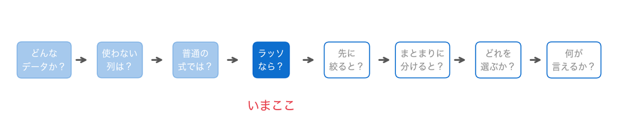

- 普通の式は、係数が自由に動きすぎた
- 第5回は、係数に罰をかけて落ち着かせた。ラッソは多くの係数をちょうど0にする

## おさらい：LassoCV

4節 ① ラッソのパイプライン●○○

```python
lasso = make_pipeline(StandardScaler(), LassoCV())
```

- `LassoCV`は、罰の強さαを交差検証で自分で選ぶラッソ（第5回の発展）
- 罰の前に標準化するので、パイプラインにする（第7回）

## お手本：ラッソを交差検証

4節 ① ラッソのパイプライン●●○

```python
lasso = make_pipeline(StandardScaler(),
                      LassoCV(cv=5, random_state=0, max_iter=5000))
scores = -cross_val_score(lasso, X_tr, y_tr, cv=kf,
                          scoring='neg_mean_absolute_error')
print(scores.round(4))
print(round(scores.mean(), 4))
```

- 符号はマイナスで返るので`-`を付ける（第5回）。1分ほどかかる

## 平均より2割小さい

4節 ① ラッソのパイプライン●●●

```
[0.0876 0.0628 0.0525 0.0776 0.0975]
0.0756
```

- 交差検証のMAEは0.0756。平均で当てた0.0959より2割ほど小さい
- 遺伝子の情報は、役に立っている

## 交差検証が2重

4節 ② 入れ子●○○

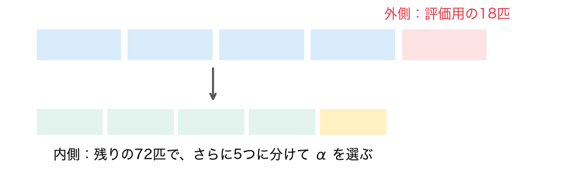

- 外側：`cross_val_score`が、90匹を5つに分け、1つを評価用に取っておく
- 内側：残りの72匹の中で、`LassoCV`がさらに5つに分けてαを選ぶ

## αを選ぶのも、答えを使う手順

4節 ② 入れ子●●○

- αは、答えを見て決める
- 外側の評価用の匹を見ずに選ぶので、評価用は「まだ見ていない匹」のまま

## 名前：入れ子の交差検証

4節 ② 入れ子●●●

- 交差検証を重ねる形を、入れ子の交差検証（nested cross-validation）と呼ぶ
- パイプラインに`LassoCV`を入れたので、入れ子は自動でできている

## お手本：作り直して数える

4節 ③ 選ばれた遺伝子●○○○○○

```python
lasso.fit(X_tr, y_tr)
print(round(lasso[-1].alpha_, 4))
print((lasso[-1].coef_ != 0).sum(), '本が0でない')
```

```
0.0012
87 本が0でない
```

- `lasso[-1]`は、パイプラインの最後の部品（第7回）

## 15,520本のうち87本

4節 ③ 選ばれた遺伝子●●○○○○

- αは0.0012。係数が0でない列は87本
- 15,520本のうち、0.6%ほどしか使っていない

## TODO②：選ばれた遺伝子の名前

4節 ③ 選ばれた遺伝子●●●○○○

```python
# TODO: 係数の絶対値が大きい5本の、係数と遺伝子の名前を表示する
# ヒント: coef = pd.Series(lasso[-1].coef_, index=X_tr.columns)
#         top5 = coef.abs().sort_values(ascending=False).index[:5]
#         genes.loc[top5, 'symbol'] で名前
...
```

- 遺伝子の名前は、表`genes`の`symbol`の列にある

## やってみよう：4節とTODO②

4節 ③ 選ばれた遺伝子●●●●○○

- 4節のお手本を実行する（1分ほどかかる）
- TODO②で、係数の大きい5本の遺伝子の名前を見る

動画の人は、ここで一時停止。

## 答え合わせ：TODO②

4節 ③ 選ばれた遺伝子●●●●●○

```python
coef = pd.Series(lasso[-1].coef_, index=X_tr.columns)
top5 = coef.abs().sort_values(ascending=False).index[:5]
print(pd.DataFrame({'係数': coef[top5].round(4),
                    '遺伝子': genes.loc[top5, 'symbol']}))
```

```
                係数    遺伝子
1378319_at -0.0247  Lime1
1388491_at  0.0167    NaN
1394038_at  0.0159  Ift81
1384504_at -0.0113  Magi1
1373281_at -0.0112   Lmf1
```

## なじみのない名前

4節 ③ 選ばれた遺伝子●●●●●●

- 名前のないプローブ（`NaN`）もある
- 研究の場では、ここから文献で働きを調べる
- 選ばれた遺伝子をどこまで信じてよいかは、6節と8節で考える

# 5. 先に絞ると？

## もっと単純な方法

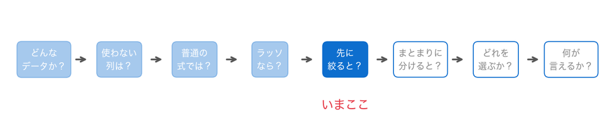

- TRIM32と相関の強い遺伝子を、先に数本だけ選ぶ
- その数本で、普通の線形回帰をする

## お手本：相関の強い10本で

5節 ① 10本で当てる●○○○

```python
r = X_tr.corrwith(y_tr)                # 各プローブと TRIM32 の相関
top10 = r.abs().sort_values(ascending=False).index[:10]
print(r[top10].round(3).values)
pipe10 = make_pipeline(StandardScaler(), LinearRegression())
scores = -cross_val_score(pipe10, X_tr[top10], y_tr, cv=kf,
                          scoring='neg_mean_absolute_error')
print(round(scores.mean(), 4))
```

- `X_tr.corrwith(y_tr)`：列1本ずつの、`y_tr`との相関係数

## ラッソよりずっと当たる？

5節 ① 10本で当てる●●○○

```
[ 0.819  0.817  0.807  0.807  0.802 -0.797  0.796  0.794  0.792  0.79 ]
0.057
```

- 10本は、どれも相関の絶対値が0.79以上
- 交差検証のMAEは0.057。ラッソの0.0756よりずっと小さい

## 0.057は、本当の当たりか？

5節 ① 10本で当てる●●●○

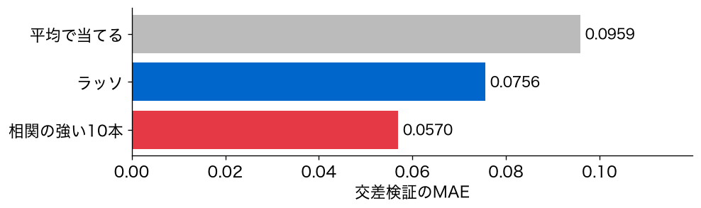

## やってみよう：問いを書く

5節 ① 10本で当てる●●●●

- この0.057を、まだ見ていないラットでの当たりとして報告してよいか
- ノートの「問い」の欄に、考えを書く

動画の人は、ここで一時停止。

## 確かめ方：答えを並べ替える

5節 ② 並べ替えて確かめる●○○○

- TRIM32の値を、ラットの間でばらばらに並べ替える
- 並べ替えると、どの遺伝子とも本当の関係はなくなる
- 関係のないデータで当たって見えたら、その手順はおかしい

## お手本：並べ替えた答えで

5節 ② 並べ替えて確かめる●●○○

```python
rng = np.random.default_rng(0)
y_shuf = pd.Series(rng.permutation(y_tr.values), index=y_tr.index)
r_s = X_tr.corrwith(y_shuf)
top_s = r_s.abs().sort_values(ascending=False).index[:10]
scores = -cross_val_score(pipe10, X_tr[top_s], y_shuf, cv=kf,
                          scoring='neg_mean_absolute_error')
base_s = []
for tr_i, te_i in kf.split(X_tr):
    base_s.append(mae(y_shuf.iloc[te_i], y_shuf.iloc[tr_i].mean()))
print(round(scores.mean(), 4), round(np.mean(base_s), 4))
```

## 1行ずつ読む

5節 ② 並べ替えて確かめる●●●○

- `permutation`：並びをばらばらに並べ替える（`0`は並べ替え方の番号）
- あとは、お手本と同じ手順（相関の強い10本を選んで交差検証）
- 最後の`for`は、並べ替えた答えを平均で当てたときのMAE

## 関係がないのに当たる

5節 ② 並べ替えて確かめる●●●●

```
0.0863 0.0954
```

- 10本の式は0.0863。平均で当てた0.0954より小さい
- 関係のないデータなのに、当たって見える

## なぜ当たって見えるのか？

5節 ③ リーク●○○

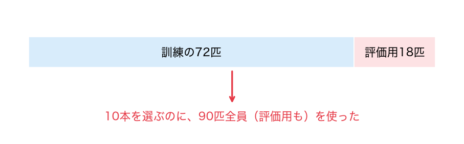

- 10本を選ぶのに、評価用の18匹の答えも使っていた

## たまたま合う遺伝子

5節 ③ リーク●●○

- 評価用の匹の答えを見て、その匹にたまたま合う遺伝子を選んでいた
- 15,520本もあれば、関係がなくても、たまたま相関の強い遺伝子が必ず見つかる

## 第2回のリークと同じ

5節 ③ リーク●●●

- リーク：答えの情報が、手がかりに漏れ込むこと（第2回）
- 今回は、選び方の手順を通して漏れ込んでいる

## 選ぶのも、各回の中で

5節 ④ 中で選ぶ●○○○○

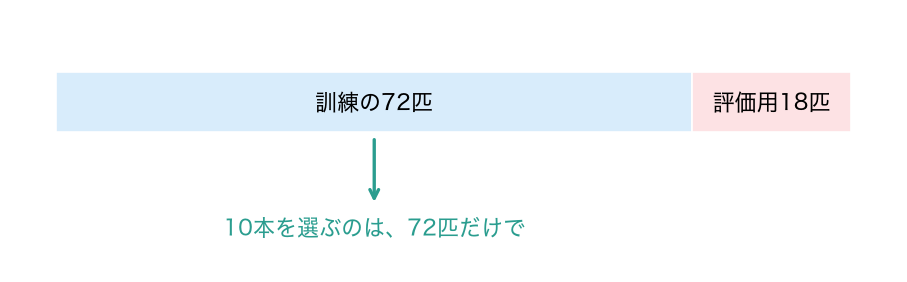

- 10本を選ぶ手順も、交差検証の各回の中で、その回の訓練の匹だけで行う

## 部品：SelectKBest

5節 ④ 中で選ぶ●●○○○

- `fit`のとき、渡された匹で、答えとの関係の強さ（`f_regression`）を列ごとに測り、強い10本を覚える
- `transform`では、その10本だけを残す
- `f_regression`の強さは、相関係数の絶対値と同じ順に並ぶ

## お手本：パイプラインの中で選ぶ

5節 ④ 中で選ぶ●●●○○

```python
sel10 = make_pipeline(StandardScaler(),
                      SelectKBest(f_regression, k=10),
                      LinearRegression())
scores = -cross_val_score(sel10, X_tr, y_tr, cv=kf,
                          scoring='neg_mean_absolute_error')
print(scores.round(4))
print(round(scores.mean(), 4))
```

- 15,520本すべてを渡す。選ぶのは、パイプラインの中

## 正しく評価すると0.0685

5節 ④ 中で選ぶ●●●●○

```
[0.0737 0.0612 0.06   0.0618 0.0856]
0.0685
```

- 先に選んだときの0.057より大きいが、ラッソの0.0756より小さい

## 正しく評価しても役に立つ

5節 ④ 中で選ぶ●●●●●

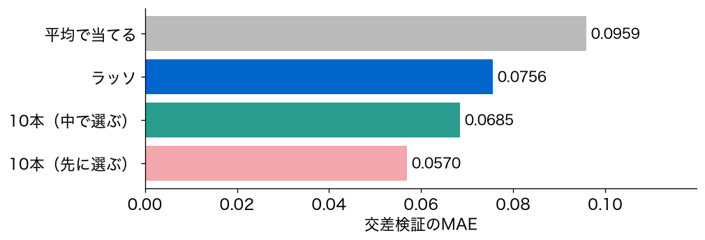

- 相関の強い遺伝子で当てる方法は、正しく評価しても、平均よりずっとよい

## TODO③：並べ替えた答えで正しく

5節 ⑤ 並べ替えて正しく●○○○○

```python
# TODO: sel10 を y_shuf で交差検証し、MAE の平均を表示する
# ヒント: お手本の cross_val_score の y_tr を y_shuf に変える
...
```

- 平均で当てたときの0.0954と比べる

## やってみよう：5節とTODO③

5節 ⑤ 並べ替えて正しく●●○○○

- 5節のお手本を実行する
- TODO③で、並べ替えた答えを正しく評価する

動画の人は、ここで一時停止。

## 答え合わせ：TODO③

5節 ⑤ 並べ替えて正しく●●●○○

```python
scores = -cross_val_score(sel10, X_tr, y_shuf, cv=kf,
                          scoring='neg_mean_absolute_error')
print(round(scores.mean(), 4))
```

```
0.1228
```

## 正しく評価すれば当たらない

5節 ⑤ 並べ替えて正しく●●●●○

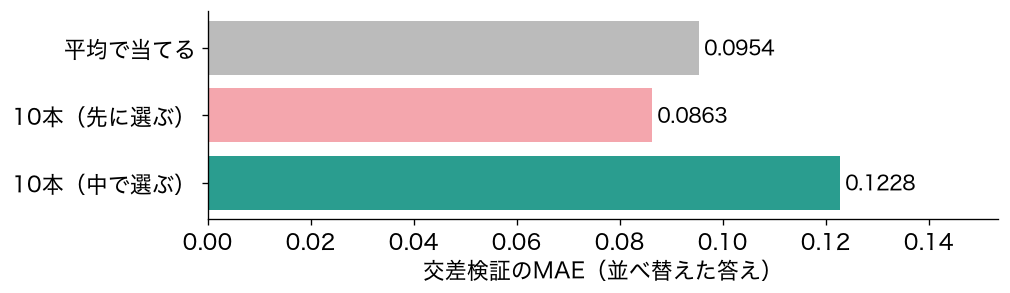

- 0.1228で、平均の0.0954より大きい。関係がないと正しく分かる

## 答えを使う手順は、すべて中へ

5節 ⑤ 並べ替えて正しく●●●●●

- 列を選ぶ、αを選ぶ、標準化の平均を決める
- どれもパイプラインに入れて、交差検証の中で行う

# 6. 遺伝子をまとまりに分けると？

## 答えを見ずに、まとまりを探す

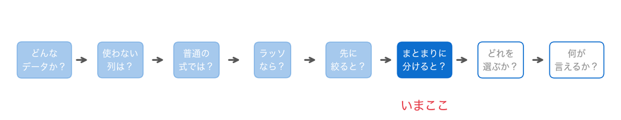

- ここまでの2つの方法は、答えのTRIM32を使って遺伝子を選んだ
- 今度は、遺伝子どうしの動き方だけから、一緒に動くまとまりを探す

## 名前：階層的クラスタリング

6節 ① 5本の例●○○

- 遺伝子をまとまりに分けるのに、階層的クラスタリング（hierarchical clustering）を使う
- 初めての方法なので、5本の小さな例から始める

## お手本：5本の相関

6節 ① 5本の例●●○

```python
ex = ['1383110_at', '1394033_at', '1376559_at', '1371242_at',
      '1379101_at']
names = genes.loc[ex, 'symbol']
print(names.values)
corr5 = X_tr[ex].corr().rename(index=names, columns=names)
print(corr5.round(2))
```

- `.rename`で、行と列の名前を、遺伝子の名前に付け替える

## 一緒に動く組、逆向きの組

6節 ① 5本の例●●●

```
        Klhl24  Rbbp9  Rpia  Grm8  Dhx36
Klhl24    1.00   0.83 -0.70 -0.62   0.02
Rbbp9     0.83   1.00 -0.69 -0.57  -0.00
Rpia     -0.70  -0.69  1.00  0.90  -0.01
Grm8     -0.62  -0.57  0.90  1.00  -0.06
Dhx36     0.02  -0.00 -0.01 -0.06   1.00
```

- Klhl24とRbbp9は0.83、RpiaとGrm8は0.90で、一緒に動く
- Klhl24とRpiaは−0.70で逆向き。Dhx36は、どれとも0に近い

## 遺伝子どうしの距離

6節 ② 距離●○○

$$d = 1 - r$$

- 一緒に動く（$r = 1$）なら0、関係がない（$r = 0$）なら1
- 逆向きに動く（$r = -1$）なら2

## お手本：距離の表

6節 ② 距離●●○

```python
dist5 = 1 - corr5
print(dist5.round(2))
```

```
        Klhl24  Rbbp9  Rpia  Grm8  Dhx36
Klhl24    0.00   0.17  1.70  1.62   0.98
Rbbp9     0.17   0.00  1.69  1.57   1.00
Rpia      1.70   1.69  0.00  0.10   1.01
Grm8      1.62   1.57  0.10  0.00   1.06
Dhx36     0.98   1.00  1.01  1.06   0.00
```

## いちばん近い組

6節 ② 距離●●●

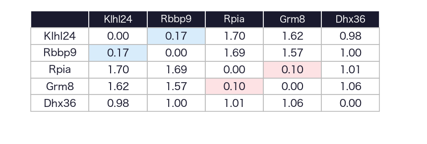

- いちばん近いのはRpiaとGrm8（0.1）、次がKlhl24とRbbp9（0.17）

## 近いものから順にまとめる

6節 ③ まとめる手順●○

1. はじめは、5本がそれぞれ1本ずつのまとまり
2. いちばん近い2つのまとまりを、1つにまとめる
3. まとまりが1つになるまで、2をくり返す

## まずは2組

6節 ③ まとめる手順●●

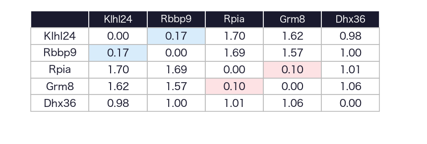

- 1回目：RpiaとGrm8（0.1）。2回目：Klhl24とRbbp9（0.17）

## まとまりどうしの距離は？

6節 ④ 群平均法●○○

- 2本がまとまったあとは、まとまりとまとまりの距離が要る
- 2つのまとまりから1本ずつ選んだ組の距離を、すべて平均する

## 名前：群平均法

6節 ④ 群平均法●●○

$$D(A, B) = \frac{1}{|A|\,|B|} \sum_{a \in A} \sum_{b \in B} d(a, b)$$

- この決め方を、群平均法（average linkage）と呼ぶ
- $|A|$、$|B|$は、まとまりの遺伝子の数

## 3回目はDhx36

6節 ④ 群平均法●●●

- Dhx36と{Klhl24, Rbbp9}：0.98と1.0の平均で0.99
- Dhx36と{Rpia, Grm8}：1.01と1.06の平均で、0.99より大きい
- 小さいほう、{Klhl24, Rbbp9}とDhx36がまとまる

## お手本：linkage

6節 ⑤ linkage●○○

```python
Z5 = linkage(X_tr[ex].T, 'average', metric='correlation')
print(Z5.round(3))
```

- `.T`で行と列を入れ替える（転置）。`linkage`は行をまとめるので、遺伝子を行にする
- `'average'`は群平均法、`metric='correlation'`は距離$1 - r$

## 1行が1回のまとめ

6節 ⑤ linkage●●○

```
[[2.    3.    0.105 2.   ]
 [0.    1.    0.174 2.   ]
 [4.    6.    0.991 3.   ]
 [5.    7.    1.443 5.   ]]
```

- 左から、まとめた2つの番号、そのときの距離、遺伝子の数
- 0〜4は5本の遺伝子（`ex`の順）、5以上はできたまとまり（5が1回目…）

## 手で計算したとおり

6節 ⑤ linkage●●●

- 1回目：2番（Rpia）と3番（Grm8）を0.105
- 2回目：0番（Klhl24）と1番（Rbbp9）を0.174
- 3回目：4番（Dhx36）と6番（2回目のまとまり）を0.991

## お手本：樹形図

6節 ⑥ 樹形図●○○○

```python
dendrogram(Z5, labels=names.values)
plt.ylabel('まとめたときの距離')
plt.show()
```

- まとめた手順を描いた図を、樹形図（dendrogram）と呼ぶ

## 高さは、まとめた距離

6節 ⑥ 樹形図●●○○

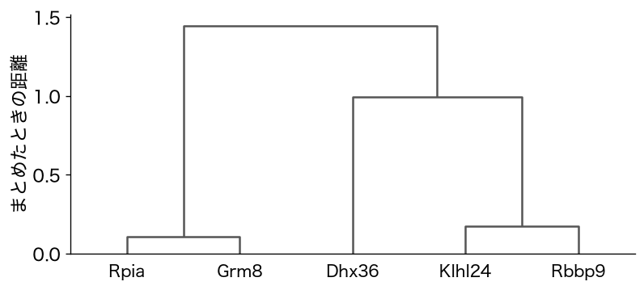

- 縦の高さが、まとめたときの距離。低くつながるほど一緒に動く

## お手本：いくつに切るか

6節 ⑥ 樹形図●●●○

```python
print(fcluster(Z5, 2, 'maxclust'))
```

```
[2 2 1 1 2]
```

- `fcluster`は、まとまりの数を決めて切る。`'maxclust'`は「数が2以下になるように」

## 横に切ると、まとまり

6節 ⑥ 樹形図●●●●

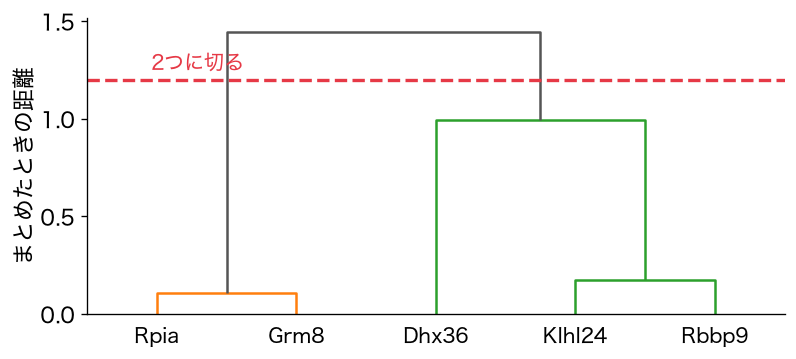

- Klhl24・Rbbp9・Dhx36と、Rpia・Grm8の2つ。これが階層的クラスタリングの全体

## 2,000本で同じことを

6節 ⑦ 2,000本●○○○

- 2,000本は、答えを見ずに、訓練の分散の大きい順に選ぶ
- ばらつきの小さい遺伝子は、一緒に動いているかを判断しにくい

## お手本：10のまとまりに

6節 ⑦ 2,000本●●○○

```python
var_top = X_tr.var().sort_values(ascending=False).index[:2000]
Z = linkage(X_tr[var_top].T, 'average', metric='correlation')
groups = pd.Series(fcluster(Z, 10, 'maxclust'), index=var_top)
print(groups.value_counts().sort_index())
```

- `pd.Series(…, index=var_top)`で、まとまりの番号にプローブの番号を付ける

## 大きさは、さまざま

6節 ⑦ 2,000本●●●○

```
1       19
2      143
3     1155
4       12
5        9
6      115
7      527
8       10
9        3
10       7
```

- 1,155本・527本・143本・115本の大きいものから、3本・7本の小さいものまで

## 2,000本の相関を色で

6節 ⑦ 2,000本●●●●

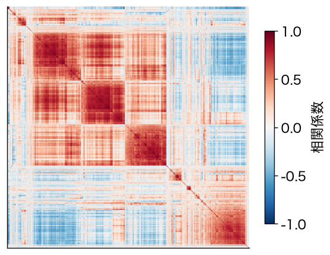

- 樹形図の順に並べた。赤は一緒に動く、青は逆向き
- 対角線に沿った赤い四角が、一緒に動くまとまり

## まとまりを1本の点数に

6節 ⑧ 点数と答え●○○○

- まとまりの遺伝子は一緒に動くので、まとめて1本の点数にする
- 遺伝子を標準化してから、まとまりの中で平均する
- ここで、初めて答えのTRIM32を使う

## お手本：点数と答えを照らす

6節 ⑧ 点数と答え●●○○

```python
Zs = (X_tr[var_top] - X_tr[var_top].mean()) / X_tr[var_top].std()
score = pd.DataFrame()
for g in range(1, 11):
    score[g] = Zs.loc[:, groups == g].mean(axis=1)   # g の平均
print(score.corrwith(y_tr).round(3))
```

## 7番と1番が強い

6節 ⑧ 点数と答え●●●○

```
1    -0.664
2    -0.134
3     0.024
4     0.033
5     0.284
6     0.294
7     0.746
8     0.072
9     0.168
10    0.041
```

## 一緒に動くまとまりが見つかった

6節 ⑧ 点数と答え●●●●

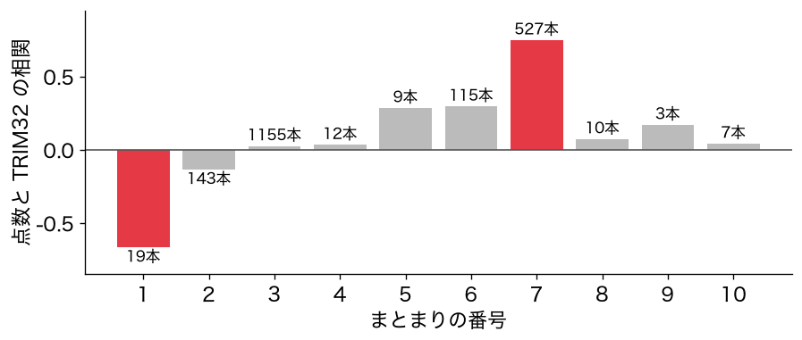

- 7番（527本）は0.746、1番（19本）は−0.664。ほかは0.3以下

## 1本ずつだと？

6節 ⑨ 平均の効果●○

```python
r7 = X_tr[var_top].corrwith(y_tr)[groups == 7]
print(round(r7.median(), 3))
```

```
0.469
```

- 7番の遺伝子1本ずつの相関は、中央値で0.469

## 平均すると雑音が打ち消し合う

6節 ⑨ 平均の効果●●

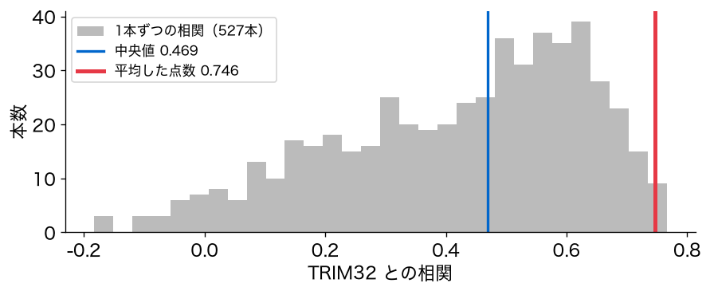

- 1本ずつの雑音が打ち消し合い、共通の動きが残る

## まとまりも、パイプラインに

6節 10 部品にする●○○○○

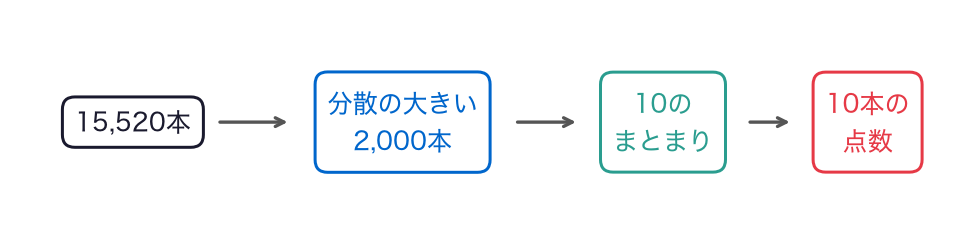

- 分散や平均を訓練で決めるので、交差検証の各回の中で行う
- 第7回の`Standardizer`と同じ形で、クラスにする

## お手本：GroupScore（覚える）

6節 10 部品にする●●○○○

```python
class GroupScore(BaseEstimator):
    def __init__(self, n_genes=2000, k=10):
        self.n_genes = n_genes
        self.k = k

    def fit(self, X, y=None):
        v = X.var().sort_values(ascending=False)
        top = v.index[:self.n_genes]
        self.mean = X[top].mean()
        self.std = X[top].std()
        Z = linkage(X[top].T, 'average', metric='correlation')
        self.groups = pd.Series(fcluster(Z, self.k, 'maxclust'),
                                index=top)
        return self
```

## お手本：GroupScore（使う）

6節 10 部品にする●●●○○

```python
    def transform(self, X):
        Zs = (X[self.groups.index] - self.mean) / self.std
        out = pd.DataFrame()
        for g in sorted(self.groups.unique()):
            out[g] = Zs.loc[:, self.groups == g].mean(axis=1)
        return out
```

- ノートでは、`fit`に続けて、同じクラスの中に書く

## 新しいのは2つ

6節 10 部品にする●●●●○

- `__init__`：部品を作るときに引数（`n_genes`、`k`）を受け取って覚える
- `(BaseEstimator)`：scikit-learnの部品の性質を受け継ぐ。`cross_val_score`に渡せる

## ブロックで読む

6節 10 部品にする●●●●●

- `fit`：分散の大きい遺伝子を選ぶ → 平均と標準偏差を覚える → まとまりに分ける
- `transform`：覚えた値で標準化し、まとまりごとの点数の表を返す
- `y=None`：答えを受け取ってもよいが、使わない

## お手本：まとまりで当てる

6節 11 まとまりで当てる●○○○○

```python
grp = make_pipeline(GroupScore(n_genes=2000, k=10),
                    LinearRegression())
scores = -cross_val_score(grp, X_tr, y_tr, cv=kf,
                          scoring='neg_mean_absolute_error')
print(scores.round(4))
print(round(scores.mean(), 4))
```

```
[0.0558 0.0544 0.0634 0.097  0.0983]
0.0738
```

## 10本の点数で、ラッソと同じくらい

6節 11 まとまりで当てる●●○○○

- 交差検証のMAEは0.0738。ラッソの0.0756と同じくらい
- 答えを見ずに作った10本の点数だけで当てた

## TODO④：まとまりの数を5に

6節 11 まとまりで当てる●●●○○

```python
# TODO: k=5 の GroupScore で交差検証し、MAE の平均を表示する
# ヒント: grp5 = make_pipeline(GroupScore(n_genes=2000, k=5),
#                              LinearRegression())
...
```

## やってみよう：6節とTODO④

6節 11 まとまりで当てる●●●●○

- 6節のお手本を上から実行する
- TODO④で、まとまりの数を5にして交差検証する

動画の人は、ここで一時停止。

## 答え合わせ：TODO④

6節 11 まとまりで当てる●●●●●

```python
grp5 = make_pipeline(GroupScore(n_genes=2000, k=5),
                     LinearRegression())
scores = -cross_val_score(grp5, X_tr, y_tr, cv=kf,
                          scoring='neg_mean_absolute_error')
print(round(scores.mean(), 4))
```

```
0.0725
```

- 0.0725で、10のときの0.0738とほとんど変わらない

# 7. どの候補を選ぶか？

## 3つの候補

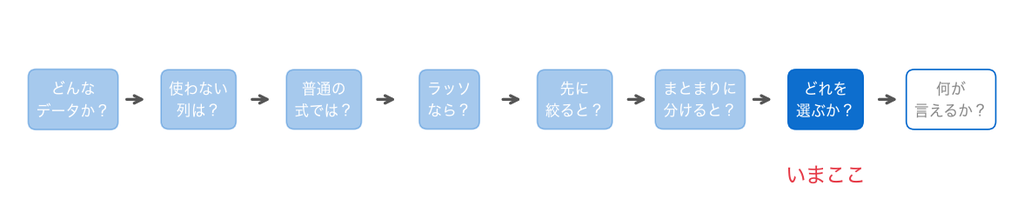

- ラッソ（0.0756）、相関の強い10本（0.0685）、まとまりの点数（0.0738）
- 選ぶ前に、今日のコードを1本のスクリプトにまとめる

## なぜ、まとめるのか

7節 ① 1本のスクリプト●○

- 途中のセルを飛ばしたり2回実行したりすると、結果が変わる（2節の`X_tr`）
- 関数に分けた1本のスクリプトなら、上から1回でいつも同じ結果
- 引数を変えるだけで比べ直せる。論文のコードも、たいていこの形

## 4つの関数

7節 ① 1本のスクリプト●●

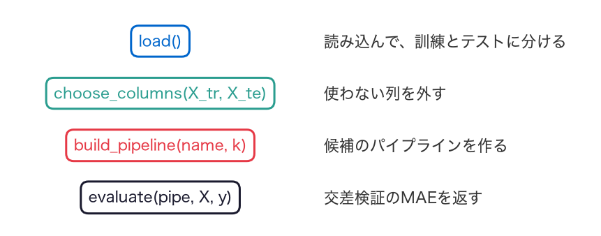

## お手本：loadとchoose_columns

7節 ② 関数にする●○○○

```python
def load():
    df = pd.read_csv(f'{DATA_DIR}/rat_eye_full.csv.gz', index_col=0)
    y = df['TRIM32']
    X = df.drop(columns='TRIM32')
    return train_test_split(X, y, test_size=0.25, random_state=0)


def choose_columns(X_tr, X_te):
    affx = X_tr.columns.str.startswith('AFFX')
    X_tr, X_te = X_tr.loc[:, ~affx], X_te.loc[:, ~affx]
    mean_tr = X_tr.mean()
    keep = mean_tr > mean_tr.median()
    return X_tr.loc[:, keep], X_te.loc[:, keep]
```

## 0節と2節のセルを並べた

7節 ② 関数にする●●○○

- `load`：0節の読み込みと分け方
- `choose_columns`：2節の、対照と発現の低いプローブを外す手順

## お手本：作る関数と評価する関数

7節 ② 関数にする●●●○

```python
def build_pipeline(name, k=10):
    if name == 'lasso':
        lasso_cv = LassoCV(cv=5, random_state=0, max_iter=5000)
        return make_pipeline(StandardScaler(), lasso_cv)
    if name == 'top':
        return make_pipeline(StandardScaler(),
                             SelectKBest(f_regression, k=k),
                             LinearRegression())
    if name == 'group':
        return make_pipeline(GroupScore(n_genes=2000, k=k),
                             LinearRegression())


def evaluate(pipe, X, y):
    scores = -cross_val_score(pipe, X, y, cv=kf,
                              scoring='neg_mean_absolute_error')
    return round(scores.mean(), 4)
```

## 名前で候補を選ぶ

7節 ② 関数にする●●●●

- `build_pipeline`：`name`で候補を選び、`k`で本数（まとまりの数）を変える
- `k=10`は、何も書かなければ10という指定（既定値）
- `evaluate`：交差検証のMAEの平均を返す

## お手本：1本のスクリプトとして

7節 ③ 実行する●○○

```python
X_tr, X_te, y_tr, y_te = load()
X_tr, X_te = choose_columns(X_tr, X_te)
for name in ['lasso', 'top', 'group']:
    print(name, evaluate(build_pipeline(name), X_tr, y_tr))
```

- このセルだけで、読み込みから比較まで動く。1分ほどかかる

## これまでと同じ数

7節 ③ 実行する●●○

```
lasso 0.0756
top 0.0685
group 0.0738
```

- いちばん小さいのは、相関の強い10本（0.0685）

## 選ぶのは交差検証で

7節 ③ 実行する●●●

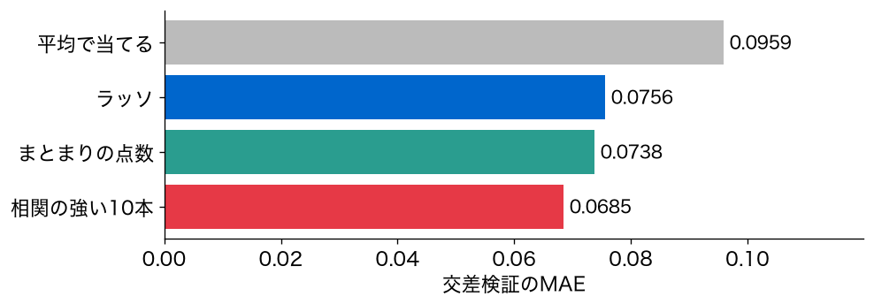

- テストで選ぶと、テストが最後の確かめにならない（第5回のαと同じ）

## TODO⑤：テストで1回だけ

7節 ④ テストで確かめる●○○○

```python
# TODO: 'top' のパイプラインを訓練で fit し、テストの MAE を出す
# ヒント: best = build_pipeline('top').fit(X_tr, y_tr)
#         mae(y_te, best.predict(X_te)) と mae(y_te, y_tr.mean())
...
```

- 平均で当てたときのテストのMAE（0.0913）と比べ、何割小さいかも出す

## やってみよう：7節とTODO⑤

7節 ④ テストで確かめる●●○○

- 7節の関数のセルと、スクリプトのセルを実行する
- TODO⑤で、選んだ候補をテストで確かめる

動画の人は、ここで一時停止。

## 答え合わせ：TODO⑤

7節 ④ テストで確かめる●●●○

```python
best = build_pipeline('top').fit(X_tr, y_tr)
m_best = mae(y_te, best.predict(X_te))
m_base = mae(y_te, y_tr.mean())
print(round(m_best, 4), round(m_base, 4))
print(f'平均で当てるより{1 - m_best / m_base:.0%}小さい')
```

```
0.0603 0.0913
平均で当てるより34%小さい
```

## テストのMAEは0.0603

7節 ④ テストで確かめる●●●●

- 平均で当てたときの0.0913より、34%小さい
- まだ見ていない30匹でも、遺伝子からTRIM32を当てられた